# mathanalysis_standardcalc110-115

```python
%%html
<style>
@import url('https://fonts.googleapis.com/css?family=Roboto&effect=3d|brick-sign|');
span {font-family:Roboto; color:black; text-shadow:4px 4px 4px #aaa;}
h1,h2 {font-family:Roboto; color:slategray; text-shadow:4px 4px 4px #aaa;}
div.output_subarea, div.output_area pre{font-family:Roboto; font_size:120%; color:darkblue;}
</style>
```

```python
import math, sympy, numpy
from sympy import *
sympy.init_printing(use_unicode=True)
import pylab as plt
%matplotlib inline
```

[GeoGebra](https://www.geogebra.org/graphing?lang=en)

LaTeX/Mathematics

[Math24.ru. Ряды Тейлора и Маклорена](http://www.math24.ru/%D1%80%D1%8F%D0%B4%D1%8B-%D1%82%D0%B5%D0%B9%D0%BB%D0%BE%D1%80%D0%B0-%D0%B8-%D0%BC%D0%B0%D0%BA%D0%BB%D0%BE%D1%80%D0%B5%D0%BD%D0%B0.html)

[Math24.ru. Бесконечно малые функции](http://www.math24.ru/%D0%B1%D0%B5%D1%81%D0%BA%D0%BE%D0%BD%D0%B5%D1%87%D0%BD%D0%BE-%D0%BC%D0%B0%D0%BB%D1%8B%D0%B5-%D1%84%D1%83%D0%BD%D0%BA%D1%86%D0%B8%D0%B8.html)

[Math24.ru. Точки разрыва функции](http://www.math24.ru/%D1%82%D0%BE%D1%87%D0%BA%D0%B8-%D1%80%D0%B0%D0%B7%D1%80%D1%8B%D0%B2%D0%B0-%D1%84%D1%83%D0%BD%D0%BA%D1%86%D0%B8%D0%B8.html)

[SymPy Modules Reference. Calculus](https://docs.sympy.org/latest/modules/calculus/index.html)

# Вариант 22

# Пределы

## Типовой расчет №10

Вычислить предел функции $\large{\displaystyle{\lim_{x \to 0} \frac { e^x + e^{-x} - 2 }{\sin ^ 2 x} }}$.

## I Способ

Числитель и знаменатель дроби стремятся к 0 при $x \to 0$,

значит дробь является неопределенным выражением вида $\big[\frac{0}{0}\big]$ при $x \to 0$.

Для раскрытия неопределенности преобразуем функцию, используя разложение в ряды Маклорена:

$\large{\displaystyle{ e^x = 1 + x + \frac{x^2}{2!} + \frac{x^3}{3!} + \frac{x^4}{4!} + \overline{o_1(x^4)} }}$

$\large{\displaystyle{e^{-x} = 1 - x + \frac{x^2}{2!} - \frac{x^3}{3!} + \frac{x^4}{4!} + \overline{o_2(x^4)} }}$

$\large{\displaystyle{ \sin^2 x = \frac{1}{2}(1 - \cos 2x) = \frac{1}{2}(1 - (1 - \frac{4x^2}{2!} + \frac{16x^4}{4!})) + \overline{o_3(x^4) }= x^2 - \frac{x^4}{3} + \overline{o_3(x^4)} }}$

$\overline{o_1(x^4)}, \ \overline{o_2(x^4)}, \ \overline{o_3(x^4)} \to 0$ при $x \to 0$.

$\large{\displaystyle{ \frac { e^x + e^{-x} - 2 }{sin ^ 2 x} = }}$

$\large{\displaystyle{= \frac { 1 + x + \frac{x^2}{2!} + \frac{x^3}{3!} + \frac{x^4}{4!} + \overline{o_1(x^4)} + 1 - x + \frac{x^2}{2!} - \frac{x^3}{3!} + \frac{x^4}{4!} + \overline{o_2(x^4)} - 2 }{x^2 - \frac{x^4}{3} + \overline{o_3(x^4)}} = }}$

$\large{\displaystyle{= \frac {(x^2 + \frac {x^4}{12} + \overline{o_1(x^4)} + \overline{o_2(x^4)}) / x^2}{(x^2 - \frac{x^4}{3} + \overline{o_3(x^4)}) / x^2} = }}$

$\large{\displaystyle{= \frac {1 + \frac {x^2}{12} + \frac{\overline{o_1(x^4)}}{x^2} + \frac{\overline{o_2(x^4)}}{x^2}} {1 - \frac{x^2}{3} + \frac{\overline{o_3(x^4)}}{x^2}} }}$

Учитывая то, что дроби $\large{\displaystyle{\frac {x^2}{12}, \frac{x^2}{3}, \frac{\overline{o_1(x^4)}}{x^2}, \frac{\overline{o_2(x^4)}}{x^2}, \frac{\overline{o_3(x^4)}}{x^2} }}$

являются бесконечно малыми величинами при $x \to 0$:

$\large{\displaystyle{\lim_{x \to 0} \frac {1 + \frac {x^2}{12} + \frac{\overline{o_1(x^4)}}{x^2} + \frac{\overline{o_2(x^4)}}{x^2}} {1 - \frac{x^2}{3} + \frac{\overline{o_3(x^4)}}{x^2}} = \frac{1 + 0 + 0 + 0}{1 - 0 + 0} = 1}}$

## II Способ

Числитель и знаменатель дроби стремятся к 0 при $x \to 0$,

значит дробь является неопределенным выражением вида $\big[\frac{0}{0}\big]$ при $x \to 0$.

Используя арифметические свойства пределов и свойства тригонометрических и показательных функций,

выполним элементарные преобразования:

$\large{\displaystyle{ = \lim_{x \to 0} \frac {(e^{\frac{x}{2}})^2 - 2 e^{\frac{x}{2}} e^{-\frac{x}{2}} + (e^{-\frac{x}{2}})^2}{\sin ^ 2 x} = \lim_{x \to 0} \Bigg(\frac { e^{\frac{x}{2}} - e^{- \frac{x}{2}} }{\sin x}\Bigg)^2 = }}$

$\large{\displaystyle{ = \lim_{x \to 0} \Bigg(\frac {e^{\frac{x}{2}} - 1 - (e^{- \frac{x}{2}} - 1)}{\sin x}\Bigg)^2 = \lim_{x \to 0} \Bigg(\frac {e^{\frac{x}{2}} - 1 - (e^{- \frac{x}{2}} - 1)}{\sin \frac{x}{2}} * \frac{\sin \frac{x}{2}}{\sin x}\Bigg)^2 = }}$

$\large{\displaystyle{ = \Bigg(\lim_{x \to 0} \frac {e^{\frac{x}{2}} - 1 - (e^{- \frac{x}{2}} - 1)}{\sin \frac{x}{2}}\Bigg)^2 * \Bigg(\lim_{x \to 0} \frac{\sin \frac{x}{2}}{\sin x} \Bigg)^2 = }}$

$\large{\displaystyle{ = \Bigg(\lim_{x \to 0} \frac {e^{\frac{x}{2}} - 1}{\sin \frac{x}{2}} + \lim_{x \to 0} \frac{e^{- \frac{x}{2}} - 1}{\sin(-\frac{x}{2})}\Bigg)^2 * \Bigg(\lim_{x \to 0} \frac{\sin \frac{x}{2}}{\sin x} \Bigg)^2 }} (*)$

Очевидно, что $\frac{x}{2} \to 0, -\frac{x}{2} \to 0$ при $x \to 0$.

Применим асимптотические равенства для бесконечно малых функций:

$\large{\displaystyle{ (e^t - 1) \sim t , \sin t \sim t \iff \frac{e^t - 1}{\sin t} \sim 1}}$

$\large{\displaystyle{ t = x \implies \lim_{x \to 0} \frac {\sin x}{x} = 1, \lim_{x \to 0} \frac {x}{\sin x} = 1}}$

$\large{\displaystyle{ t = \frac {x}{2} \implies \lim_{x \to 0} \frac {e^{\frac{x}{2}} - 1}{\sin \frac{x}{2}} = 1, \ \lim_{x \to 0} \frac {\sin \frac{x}{2}}{\frac{x}{2}} = 1}}$

$\large{\displaystyle{ t = -\frac {x}{2} \implies \lim_{x \to 0} \frac {e^{-\frac{x}{2}} - 1}{\sin(-\frac{x}{2})} = 1 }}$

$\large{\displaystyle{ \Bigg( \lim_{x \to 0} \frac{ \sin \frac{x}{2} } {\sin x}\Bigg)^2 = \frac{1}{4} * \Bigg( \lim_{x \to 0} \frac{ \sin \frac{x}{2} }{\sin x} * \frac{x}{\frac{x}{2}} \Bigg)^2 = }}$

$\large{\displaystyle{ = \frac{1}{4} * \Bigg( \lim_{x \to 0} \frac{ \sin \frac{x}{2} }{\frac{x}{2}} \Bigg)^2 * \Bigg( \lim_{x \to 0} \frac{ x }{\sin x} \Bigg)^2 = \frac{1}{4} * 1^2 * 1^2 = \frac{1}{4} }}$

$\large{\displaystyle{ \implies (*) = (1 + 1)^2 * \frac{1}{4} = 1}}$

```python
N(E)
```

$$2.71828182845905$$

```python
x = symbols('x')
limit((E ** x + E ** (-x) - 2) / (sin(x)) ** 2, x, 0)
```

$$1$$

## Типовой расчет №11

Вычислить предел функции $\large{\displaystyle{\lim_{x \to \pi} \frac {\ln \cos 2x}{(x - \pi)^2} }}$.

## Решение

Числитель и знаменатель дроби стремятся к 0 при $x \to \pi$,

значит дробь является неопределенным выражением вида $\big[\frac{0}{0}\big]$ при $x \to \pi$.

Для раскрытия неопределенности преобразуем функцию, используя формулы эквивалентности функций.

Прежде всего произведем замену переменной $x - \pi = t \iff x = t + \pi; \ x \to \pi \implies t \to 0$.

$\large{\displaystyle{\lim_{x \to \pi} \frac {\ln \cos 2x}{(x - \pi)^2} = \lim_{t \to 0} \frac {\ln \cos (2t + 2\pi)}{t^2} = \lim_{t \to 0} \frac {\ln (1 + (\cos 2t - 1))}{t^2} = \lim_{t \to 0} \frac {\cos 2t - 1}{t^2}}}$

Здесь использована формула эквивалентности $\ln(1 + a) \sim a$ при $a \to 0$.

Поскольку $cos2t - 1 \to 0$ при $t \to 0$, то $\ln (1 + (\cos 2t - 1)) \sim cos2t - 1$ при $t \to 0$.

Применим формулу синуса половинного угла $\sin^2 a = \frac{1 - cos 2 a}{2}$ и арифметические свойства пределов:

$\large{\displaystyle{\lim_{t \to 0} \frac {\cos 2t - 1}{t^2} = \lim_{t \to 0} \frac {-2\sin^2t}{t^2} = -2 \Bigg(\lim_{t \to 0} \frac {\sin t}{t}\Bigg)^2}}$

С учетом первого замечательного предела $\displaystyle{\lim_{a \to 0} \frac{\sin a}{a} = 1}$:

$\large{\displaystyle{-2 \Bigg(\lim_{t \to 0} \frac {\sin t}{t}\Bigg)^2 = -2 * 1^2 = -2}}$

```python
N(pi)
```

$$3.14159265358979$$

```python
x = symbols('x')
limit(ln(cos(2 * x)) / (x - pi) ** 2, x, pi)
```

$$-2$$

## Типовой расчет №12

Вычислить предел функции $\large{\displaystyle{\lim_{x \to 0} \Bigg(\frac {2x + 9}{x + 9}\Bigg)^{1/(\sqrt[3]{x + 8} - 2)} }}$.

## Решение

$\large{\displaystyle{\frac {2x + 9}{x + 9} \to 1; \frac{1}{\sqrt[3]{x + 8} - 2} \to \infty}}$ при $x \to 0$, значит

функция является неопределенным выражением вида $\big[1^{\infty}\big]$ при $x \to 0$.

Для раскрытия неопределенности воспользуемся

- вторым замечательным пределом и
- известной схемой его применения.

Пусть $g(x) \to \infty, h(x) \to 0$ при $x \to 0$.

Поскольку показательная функция $e^t, \ \forall t \in \mathbb{R}$ непрерывна, то справедливы следующие равенства:

$\large{\displaystyle{\lim_{x \to 0}\bigg(1 + h(x)\bigg)^{g(x)} = \lim_{x \to 0}\Bigg[\bigg(1 + h(x)\bigg)^{\frac{1}{h(x)}}\Bigg]^{h(x)g(x)} = \lim_{x \to 0} e^{h(x)g(x)} }}$

Примения эту схему к данному примеру, получим:

$\large{\displaystyle{h(x) = 1 - \frac {2x + 9}{x + 9} = \frac {x + 9 - 2x - 9}{x + 9} = -\frac{x}{x+9} \to 0}}$ при $x \to 0$

$\large{\displaystyle{g(x) = \frac{1}{\sqrt[3]{x + 8} - 2} \to \infty}}$ при $x \to 0$

$\large{\displaystyle{\lim_{x \to 0} \Bigg(\frac {2x + 9}{x + 9}\Bigg)^{1/(\sqrt[3]{x + 8} - 2)} = \lim_{x \to 0} e^ {-\frac{x}{x+9} \frac{1}{\sqrt[3]{x + 8} - 2}} = \lim_{x \to 0} e^ \frac{x}{(x + 9)(2 - \sqrt[3]{x + 8})} }}$

Применим тождественные преобразования выражений и арифметические свойства предела:

$\large{\displaystyle{ \frac{x}{(x + 9)(2 - \sqrt[3]{x + 8})} = \frac{x}{2x + 18 - x\sqrt[3]{x + 8} - 9\sqrt[3]{x + 8}} = }}$

$\large{\displaystyle{= \frac{x}{2x + 18 - \sqrt[3]{x^4 + 8x^3} - \sqrt[3]{729x + 5832}} }}$

$\large{\displaystyle{ \lim_{x \to 0}\frac{x}{2x + 18 - \sqrt[3]{x^4 + 8x^3} - \sqrt[3]{729x + 5832}} = \frac{0}{0 + 18 - 0 - \sqrt[3]{5832}} = 0 \implies }}$

$\large{\displaystyle{ \lim_{x \to 0} e^ {\frac{x}{(x + 9)(2 - \sqrt[3]{x + 8})}} = e^0 = 1}}$

```python
x = symbols('x')
limit(((2*x + 9) / (x + 9)) ** ((x + 8) ** (1/3) - 2), x, 0)
```

$$1$$

## Типовой расчет №13

Вычислить предел функции $\large{\displaystyle{\lim_{x \to \infty} \Bigg(\frac {x}{x - 1}\Bigg)^{3 - 2x} }}$.

## Решение

$\frac {x}{x - 1} \to 1$; $3 - 2x \to \infty$ при $x \to \infty$, значит

функция является неопределенным выражением вида $\big[1^{\infty}\big]$ при $x \to \infty$.

Заменим переменную: $ y = \frac{1}{x} \iff x = \frac{1}{y}$, причем $y \to 0, \frac{1}{y} \to \infty$ при $x \to \infty$.

$\large{\displaystyle{\lim_{x \to \infty} \Bigg(\frac {x}{x - 1}\Bigg)^{3 - 2x} = \lim_{x \to \infty} \Bigg(\frac {x - 1}{x}\Bigg)^{2x - 3} = \lim_{x \to \infty} \Bigg(1 - \frac {1}{x}\Bigg)^{2x - 3} = }}$

$\large{\displaystyle{= \lim_{y \to 0} \bigg(1 - y\bigg)^{\frac{2}{y} - 3} = \lim_{y \to 0} \bigg(1 - y\bigg)^{\frac{2 - 3y}{y}} = \lim_{y \to 0} \Bigg[ \bigg(1 + (-y) \bigg)^{\frac{1}{-y}} \Bigg] ^{3y - 2} (*) }}$

Применяя формулу второго замечательного предела, получим:

$\large{\displaystyle{-y \to 0, \frac{1}{-y} \to \infty \implies \lim_{y \to 0} \bigg(1 + (-y) \bigg)^{\frac{1}{-y}} = e \implies}}$.

Поскольку показательная функция $e^t, \ \forall t \in \mathbb{R}$ непрерывна:

$\large{\displaystyle{ (*) = \lim_{y \to 0} e^{3y -2} = e^{-2} }}$.

```python
x = symbols('x')
limit(( x / (x - 1) ) ** (3 - 2 * x), x, oo)
```

$$e^{-2}$$

## Типовой расчет №14

Сравнить бесконечно малые при $x \to x_0$ функции $\alpha(x)$ и $\beta(x)$.

$\alpha(x) = \sin (3x - 2)^2; \ \beta(x) = ch(2 - 3x) - 1; \ x_0 = \frac{2}{3}$

## Решение

Чтобы сравнить заданные функции $\alpha(x)$ и $\beta(x)$ при $x \to x_0$,

найдем предел частного $\large{\displaystyle{\lim_{x \to \frac {2}{3}} \frac {\sin (3x - 2)^2}{ch(2 - 3x) - 1} (*)}}$

Заменим переменную: $ y = 2 - 3x \iff x = \frac{2 - y}{3}$, причем $y \to 0, \frac{1}{y} \to \infty$ при $x \to \frac {2}{3}$.

и подставим соотвествующее выражение для гиперболического косинуса $ch \ t = (e^t + e^{-t})/2$.

$\large{\displaystyle{(*) = \lim_{y \to 0} \frac {\sin (-y)^2}{ch \ y - 1} = \lim_{y \to 0} \frac {\sin (y^2)}{(e^y + e^{-y})/2 - 1} = \lim_{y \to 0} \frac {2\sin (y^2)}{e^y + e^{-y} - 2} (**) }}$

Используем правило Лопиталя

$\large{\displaystyle{\lim_{x \to 0} \frac { f(x) }{ g(x) } = \lim_{x \to 0} \frac { f'(x) }{ g'(x) } }}$

и дважды продифференцируем числитель и знаменатель:

$\large{\displaystyle{(**) = \lim_{y \to 0} \frac {(2\sin (y^2))'}{(e^y + e^{-y} - 2)'} = \lim_{y \to 0} \frac {4y\cos (y^2)}{e^y - e^{-y}} = }}$

$\large{\displaystyle{= \lim_{y \to 0} \frac {(4y\cos (y^2))'}{(e^y - e^{-y})'} = \lim_{y \to 0} \frac {-8 y^2 sin(y^2) + 4\cos (y^2)}{e^y + e^{-y}} = \frac{0 + 4}{1 + 1} = 2}}$

```python
y = symbols('y')
diff(2 * sin(y ** 2) , y)
```

$$4 y \cos{\left (y^{2} \right )}$$

```python
diff(E ** y + E ** (-y) - 2, y)
```

$$e^{y} - e^{- y}$$

```python
diff(diff(2 * sin(y ** 2) , y),y)
```

$$- 8 y^{2} \sin{\left (y^{2} \right )} + 4 \cos{\left (y^{2} \right )}$$

```python
diff(diff(E ** y + E ** (-y) - 2, y), y)
```

$$e^{y} + e^{- y}$$

```python
x = symbols('x')
limit(sin((3 * x - 2) ** 2) / (cosh(2 - 3 * x) - 1), x, 2/3)
```

$$2$$

## Типовой расчет №15

Найти точки разрыва функции и установить их характер.

$\large{\displaystyle{ f(x) = \frac{1 - \cos 6x}{4 x^2} }}$

## Решение

Функция $f(x)$ определена и непрерывна для всех $x \in \mathbb{R}$, кроме $x = 0$, т.е.

$f(x)$ непрерывна на всей области определения $(-\infty, 0) \cup (0, +\infty)$.

В точке $x = 0$ функция $f(x)$ имеет разрыв, т.к. она определена в некоторой проколотой окрестности

этой точки, а в самой точке не определена.

Для классификации тип разрыва, вычислим односторонние пределы при $x \to 0$.

Учитывая вид неопределенности, при вычислении предела используем правило Лопиталя

$\large{\displaystyle{\lim_{x \to 0} \frac { f(x) }{ g(x) } = \lim_{x \to 0} \frac { f'(x) }{ g'(x) } }}$

и дважды продифференцируем числитель и знаменатель:

$\large{\displaystyle{\lim_{x \to 0 - 0} \frac{1 - \cos 6x}{4 x^2} = \Bigg[ \frac{0}{0} \Bigg] = \lim_{x \to 0 - 0} \frac{(1 - \cos 6x)'}{(4 x^2)'} = }}$

$\large{\displaystyle{= \lim_{x \to 0 - 0} \frac{6 \sin 6x}{8x} = \lim_{x \to 0 - 0} \frac{(6 \sin 6x)'}{(8x)'} = \lim_{x \to 0 - 0} \frac{36 \cos 6x}{8} = \frac {36 * 1}{8} = 4.5}}$.

Аналогично

$\large{\displaystyle{\lim_{x \to 0 + 0} \frac{1 - \cos 6x}{4 x^2} = \Bigg[ \frac{0}{0} \Bigg] = \lim_{x \to 0 + 0} \frac{36 \cos 6x}{8} = \frac {36 * 1}{8} = 4.5}}$

Левосторонний и правосторонний пределы существуют и конечны, значит

$x = 0$ является *точкой разрыва первого рода*.

$\large{\displaystyle{\lim_{x \to 0 - 0} f(x) = \lim_{x \to 0 + 0} f(x) = 4.5}}$

Левосторонний и правосторонний пределы равны, значит

$x = 0$ является *точкой устранимого разрыва*.

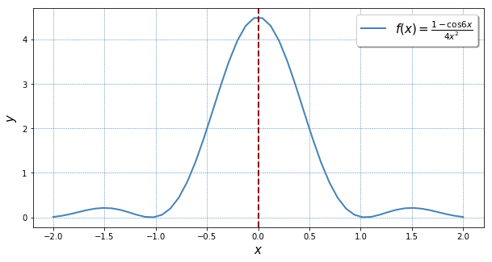

```python
x = numpy.linspace(-2.0,2.0)
y = (1 - numpy.cos(6 * x)) / (4 * x ** 2)

plt.figure(figsize=(10,5)); plt.grid(c='steelblue',ls='--',lw=0.5)
plt.plot(x, y, c='steelblue', lw=2, label=r'$f (x) = \frac{1 - \cos 6x}{4 x^2}$')
plt.axvline(0, c='darkred',ls='--',lw=2)

plt.xlabel(r'$x$', fontsize=15); plt.ylabel(r'$y$', fontsize=15)
plt.legend(fontsize=15, shadow=True);
```

```python
x = symbols('x')
diff(1 - cos(6 * x) , x), diff(diff(1 - cos(6 * x) , x), x)
```

$$\left ( 6 \sin{\left (6 x \right )}, \quad 36 \cos{\left (6 x \right )}\right )$$

```python
diff(4 * x ** 2, x), diff(diff(4 * x ** 2, x), x)
```

$$\left ( 8 x, \quad 8\right )$$

```python
limit( (1 - cos(6 * x)) / (4 * x ** 2), x, 0, '+')
```

$$\frac{9}{2}$$

```python
limit( (1 - cos(6 * x)) / (4 * x ** 2), x, 0, '-')
```

$$\frac{9}{2}$$